```python
# import os related libraries for finding stuff
import os
from pathlib import Path, PurePath, PureWindowsPath  # notebook often run on Win platforms
import locale

# import core python libraries for analysis
import pandas as pd
import numpy as np

# EDA helper imports
import missingno as msno

from sklearn.cluster import KMeans
import category_encoders as ce
# sample usage
# encoder = ce.BackwardDifferenceEncoder(cols=[...])
# encoder = ce.BinaryEncoder(cols=[...])
# encoder = ce.HashingEncoder(cols=[...])
# encoder = ce.HelmertEncoder(cols=[...])
# encoder = ce.OneHotEncoder(cols=[...])
# encoder = ce.OrdinalEncoder(cols=[...])
# encoder = ce.SumEncoder(cols=[...])
# encoder = ce.PolynomialEncoder(cols=[...])
# encoder = ce.BaseNEncoder(cols=[...])
# encoder = ce.TargetEncoder(cols=[...])
# encoder = ce.LeaveOneOutEncoder(cols=[...])

# import visualization libraries, and do some configuration of this jupyter notebook
import plotly
import bokeh
import seaborn as sns
import matplotlib
import matplotlib.pyplot as plt
import matplotlib.dates as mdates
%matplotlib inline
from IPython.core.display import display, HTML
display(HTML("<style>.container { width:100% !important; }</style>"))

from bokeh.plotting import figure
from bokeh.plotting import output_file, output_notebook , show
from bokeh.io import show, output_notebook
from bokeh.io import export_png
from bokeh.models import ColumnDataSource, HoverTool, CategoricalColorMapper
from bokeh.palettes import Category10_5, Category20_16

# enable multiple outputs per cell
from IPython.core.interactiveshell import InteractiveShell
InteractiveShell.ast_node_interactivity = "all"
```

# Using Python and Data Science for Social Good

**Chris Brousseau**

2018.12.20

# About me

**Chris Brousseau**

*Surface Owl - Founder & Data Scientist*  
*Pragmatic AI Labs - Cloud-Native ML*

Prior work at Accenture & USAF  
Engineering @Boston University

# Project Overview

*UK Government*

*Community Rehabilitation Company*

Court ordered office visits / community service

~40,000 - 50,000 people annually

# Disclaimers

1- All data shared was anonymized by client before receipt  
2- For this talk - new data generated for people related datasets

# Data Science - before we start

**What questions are we trying to answer?**

*1 -* What is current state? (understand and map source data)

*2 -* How should the city reorganize to improve? (attendance and completion rates)

# Agenda

| Agenda Item | Why valuable today? |
| --- | --- |
| EDA & Data Cleanup | library - missingno |
| API for validating UK postcodes | use of 3rd party API with python |
| Google Distance Matrix API | cartesian join & demo Google API |
| Maps in Folium | geomapping data / Folium |

# EDA & Data Cleanup - starting point

| file | contents | # of datapoints |
| --- | --- | --- |
| 01 - project users.xlsx | USERS - Community Service Users | ~30,000 - 40,000 +/- |

[output not shown]

## Postcodes - Interesting Differences between US & UK

| quality | US Zip Code | *UK Postcode* |
| --- | --- | --- |
| example | 94402 | NW3 2NL |
| total num | 42,000 | 1,766,544 |
| avg population per code | 7,834 | ~40 |
| avg num houses | 3,036 | 15 |

*Note: US assumed 2.58 people per household*

## Last Attended Band

```python
# hidden - setup data
input_excel_file = "../data.secure/baypiggies/baypiggies01.local_anon_users.xlsx"
```

```python
# What's in the data?
df = pd.read_excel(input_excel_file, sheet_name=0)

# cast all column names to lowercase for ease of merging later
df = df.rename(str.lower, axis='columns')
df.info()
```

```
<class 'pandas.core.frame.DataFrame'>
RangeIndex: 9036 entries, 0 to 9035
Data columns (total 14 columns):
reference             9036 non-null int64
entry event num       9036 non-null int64
exit prediction       9036 non-null object
due date              9036 non-null object
a/b                   9036 non-null object
age band              9036 non-null int64
postcode              9036 non-null object
num standdowns std    3032 non-null float64
last attended band    9036 non-null object
order ageing band     9036 non-null object
bill                  9036 non-null int64
paid                  9036 non-null float64
outstanding           9036 non-null float64
actively working      9036 non-null object
dtypes: float64(3), int64(4), object(7)
memory usage: 741.3+ KB
```

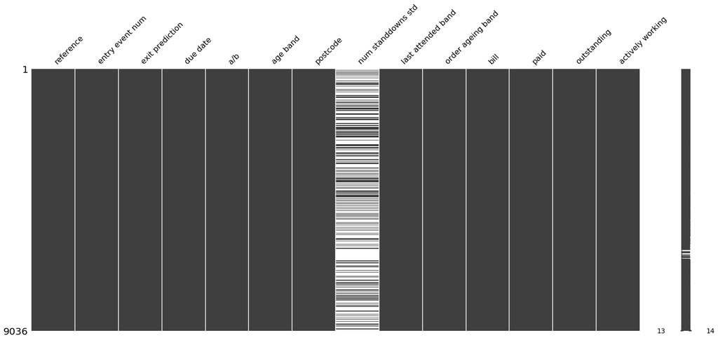

```python
# missingno - useful library - quickly see state of data; use early in your project

# https://pypi.org/project/missingno/   -- pip install missingno
# https://github.com/ResidentMario/missingno
msno.matrix(df);
#
```

```python
# object_columns = df.columns.values.tolist()
object_columns = ['num standdowns std']
threshold = 25

# loop through columns, and add stats about each column and values
for column in object_columns:
    shortlist = df[column].value_counts().nlargest(threshold)
    print(column, "\n# of unique values:", df[column].nunique(), "\n\n top values & # entries:\n",shortlist, "\n")
#
```

```
num standdowns std
# of unique values: 20

 top values & # entries:
 1.0     1353
2.0      631
3.0      367
4.0      210
5.0      153
6.0       98
7.0       57
8.0       45
9.0       34
10.0      24
11.0      20
12.0      14
13.0      12
14.0       4
16.0       3
15.0       3
18.0       1
28.0       1
25.0       1
19.0       1
Name: num standdowns std, dtype: int64
```

```python
# what about the quality of another column
object_columns = ['last attended band']
threshold = 25

# loop through columns, and add stats about column and values to our new dataframe
for column in object_columns:
    shortlist = df[column].value_counts().nlargest(threshold)
    print(column, "\n# of unique values: ", df[column].nunique(), "\n\n top values & # entries:\n",shortlist,"\n\n")

#
```

```
last attended band
# of unique values:  4

 top values & # entries:
 0-2                    3337
0                      2428
6+                     2348
2018-06-02 00:00:00     923
Name: last attended band, dtype: int64
```

```python
# hidden data cleanup
# convert Due Date to type datetime for sorting, grouping
df['due date'] = pd.to_datetime(df['due date'], yearfirst=True)

# the Last Attended band has 923 actual dates, vs # of months since last attended, lets fix
df['last attended band'] = df['last attended band']

#there are a few categorical columns
df['exit prediction'] = df['exit prediction'].astype('category')
df['a/b'] = df['a/b'].astype('category')
df['age band'] = df['age band'].astype('category')
df['last attended band'] = df['last attended band'].astype('category')
df['order ageing band'] = df['order ageing band'].astype('category')
df['actively working'] = df['actively working'].astype('category')

# fillna to zero on standdowns, cast categories to int
df['num standdowns std'] = df['num standdowns std'].fillna(value=0)
df['num standdowns std'] = df['num standdowns std'].astype('int64')

# review cleaned up dataframe
df.info()
#
```

```
<class 'pandas.core.frame.DataFrame'>
RangeIndex: 9036 entries, 0 to 9035
Data columns (total 14 columns):
reference             9036 non-null int64
entry event num       9036 non-null int64
exit prediction       9036 non-null category
due date              9036 non-null datetime64[ns]
a/b                   9036 non-null category
age band              9036 non-null category
postcode              9036 non-null object
num standdowns std    9036 non-null int64
last attended band    9036 non-null category
order ageing band     9036 non-null category
bill                  9036 non-null int64
paid                  9036 non-null float64
outstanding           9036 non-null float64
actively working      9036 non-null category
dtypes: category(6), datetime64[ns](1), float64(2), int64(4), object(1)
memory usage: 583.0+ KB
```

```python
# hidden data cleanup
df['last attended band'] = df['last attended band'].astype("str")

unique_in_last_attended = df['last attended band'].unique()
for item in unique_in_last_attended:
    print(item)
print("\n")

# let's replace "2018-06-02 00:00:00" with # of months from today
print("Cleaned up - last attended band")
df['last attended band'] = pd.Series(df['last attended band']).apply(lambda s: s.replace('2018-06-02 00:00:00', '5+'))

unique_in_last_attended = df['last attended band'].unique()
unique_in_last_attended.sort()
for item in unique_in_last_attended:
    print(item)
#
```

```
6+
0-2
0
2018-06-02 00:00:00


Cleaned up - last attended band
0
0-2
5+
6+
```

```
 Correlation Matrix for all the variables in this data
```

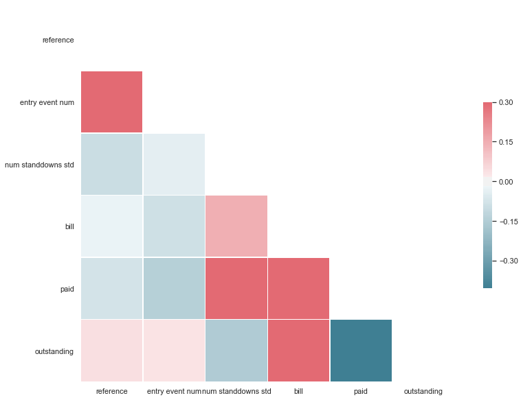

```python
# create correlation matrix for our data
sns.set(style="white")

# get data for plot
d = df

# Compute the correlation matrix
corr = d.corr()

# Generate a mask for the upper triangle
mask = np.zeros_like(corr, dtype=np.bool)
mask[np.triu_indices_from(mask)] = True

# Set up the matplotlib figure
f, ax = plt.subplots(figsize=(15, 10))

# Generate a custom diverging colormap
cmap = sns.diverging_palette(220, 10, as_cmap=True)

print("\n\n Correlation Matrix for all the variables in this data")
# Draw the heatmap with the mask and correct aspect ratio
sns.heatmap(corr, mask=mask, cmap=cmap, vmax=.3, center=0,
            square=True, linewidths=.5, cbar_kws={"shrink": .5});
```

```python
df.drop('reference', axis=1, inplace=True)
df.drop('entry event num', axis=1, inplace=True)
```

### Lessons to Highlight

1- "automatic" graphical inspections save you time  
2- missingno highlights potential data gaps automatically  
3- AND you still need to inspect your data manually

## Our Approach to the Project

0 - locate all people and project/office locations  
... analyze + map + map pairwise combinations  
1- validate locations - postcode API  
2- errors - throw out rows with errors & tell client about sources to fix  
3- get geo data  
4- find distances & times between locations - Google API create map

**Limitations to consider -** speed of postcode API, cost of google distance matrix

**strategy -** --(min cost/time) ==> get API and analysis working ==> then productize  
-- take data in small bites  
-- save intermediate results & iterate

```python
# we have Postcodes for all users and locations
# ...but that isn't directly mappable
# Let's use an API to help enrich our data

from PostCodeClient import PostCodeClient
# https://pypi.org/project/uk-postcode-validator/
# https://github.com/jayakrishnandingit/uk_postcode_validator
# souce data for API: https://postcodes.io/
# Royal Mail:  https://www.royalmail.com/find-a-postcode

import json
from pandas.io.json import json_normalize #package for flattening json in pandas df
```

```python
def check_postcodes_exist(postcodes_unique):
    """
    Function to confirm if UK postcodes exist or not

    :param postcodes_unique: list of unique postcodes in a list
    :return two lists, separating correct from incorrect postcodes
    """

    postcodes_unique = set(postcodes_unique)
    postcodes_unique_exist = []
    postcodes_unique_nonexist =[]

    for postcode_to_test in postcodes_unique:
        client = PostCodeClient()
        # library returns a string that "looks like" a dict
        # so we parse result by json loads
        test_result = json.loads(client.validatePostCode(postcode_to_test))
        postcode_tested = postcode_to_test

        if test_result.get("result") != True:
            postcodes_unique_nonexist.append(postcode_tested)
        else:
            postcodes_unique_exist.append(postcode_tested)

    return postcodes_unique_exist, postcodes_unique_nonexist
#
```

```python
# LIVE DEMO
# take small sample of postcodes
# summarize wrong postcodes, for future deletion

df_sample = df.sample(20)

postcodes_unique = df_sample['postcode'].unique().tolist()

[postcodes_unique_exist, postcodes_unique_nonexist] = \
check_postcodes_exist(postcodes_unique)

print("\n Correct postcodes = ", postcodes_unique_exist)
print("\n\n Incorrect postcodes in source = ", postcodes_unique_nonexist)
#
```

```
 Correct postcodes =  ['E3 3LT', 'NW10 1DU', 'W3 6RN', 'SE15 5SZ', 'NW10 2HD', 'HA0 4UN', 'SW15 2RA', 'UB5 5AN', 'SE18 2NS', 'TW13 7BB', 'RM3 9JT', 'SE1 7JR', 'SW9 0BN', 'N20 0QU', 'N17 6DL', 'RM8 3QT', 'N15 4EA', 'IG10 1LS', 'TW14 9EG', 'BR6 8JE']


 Incorrect postcodes in source =  []
```

```python
def get_geo_data(source_dataframe):
    """
    Function to get geodata from the UK PostCodeClient API

    :param source_dataframe: input_dataframe, must contain column titled 'postcode'
    :return dataframe with rows of postcodes with geo data; one result per row
    """

    client = PostCodeClient()

    postcodes_unique = source_dataframe['postcode'].unique().tolist()

    # feed only postcodes that exist to geolocate API
    [postcodes_unique_exist, postcodes_unique_nonexist] = \
    check_postcodes_exist(postcodes_unique)

    # define headers we want in final dataframe; setup dataframe
    # 28 data elements available
    # e.g. exclude:  northings, Westminster Parliamentary Constituency, etc.
    header_columns = ['postcode', 'latitude','longitude','region', 'country']
    results_dataframe = pd.DataFrame(columns=header_columns)

    for lookup_code in postcodes_unique_exist:
        result_raw = client.getLookupPostCode(lookup_code)
        result_json = json.loads(result_raw)
        result_flattened = json_normalize(result_json['result'])

        # get only the columns we want
        resulting_row = result_flattened[header_columns]
        # append result to our dataframe
        results_dataframe = results_dataframe.append(resulting_row)

    return results_dataframe

#
```

```python
# LIVE DEMO
get_geo_data(df_sample)
#
```

|  | postcode | latitude | longitude | region | country |
| --- | --- | --- | --- | --- | --- |
| 0 | E3 3LT | 51.521804 | -0.012420 | London | England |
| 0 | NW10 1DU | 51.555349 | -0.244654 | London | England |
| 0 | W3 6RN | 51.516741 | -0.260921 | London | England |
| 0 | SE15 5SZ | 51.475094 | -0.066594 | London | England |
| 0 | NW10 2HD | 51.545659 | -0.236672 | London | England |
| 0 | HA0 4UN | 51.549420 | -0.307056 | London | England |
| 0 | SW15 2RA | 51.458514 | -0.209472 | London | England |
| 0 | UB5 5AN | 51.543433 | -0.373313 | London | England |
| 0 | SE18 2NS | 51.478785 | 0.094468 | London | England |
| 0 | TW13 7BB | 51.439306 | -0.406942 | London | England |
| 0 | RM3 9JT | 51.604940 | 0.233668 | London | England |
| 0 | SE1 7JR | 51.493119 | -0.119940 | London | England |
| 0 | SW9 0BN | 51.469742 | -0.114551 | London | England |
| 0 | N20 0QU | 51.625028 | -0.175128 | London | England |
| 0 | N17 6DL | 51.596594 | -0.084237 | London | England |
| 0 | RM8 3QT | 51.557840 | 0.128410 | London | England |
| 0 | N15 4EA | 51.588070 | -0.067287 | London | England |
| 0 | IG10 1LS | 51.656219 | 0.064009 | East of England | England |
| 0 | TW14 9EG | 51.457115 | -0.414599 | London | England |
| 0 | BR6 8JE | 51.372911 | 0.068110 | London | England |

```python
# GOAL - create function to merge geo data with source DataFrame

def merge_geo_data(source_dataframe):
    """
    Function merges  geo data with source DataFrame

    :param source_dataframe: DataFrame with UK postcodes
    :return new dataframe with appended geo data: 'postcode', 'latitude','longitude','region', 'country' for each code

    """
    # get new geo data using existing function
    dataframe_results = get_geo_data(source_dataframe)

    # merge with a LEFT join, since the left table is our master CSV - we don't want to introduce any NaN values
    source_dataframe = pd.merge(left=source_dataframe,
                                right=dataframe_results, how='left')

    return source_dataframe
```

```python
# LIVE DEMO

from time import sleep

# tie it all together
for loop in range(3):
    df_sample_postcodes = df.sample(3)
    merge_geo_data(df_sample_postcodes)
    sleep(3)

# finally - we export as csv (not shown)
```

|  | exit prediction | due date | a/b | age band | postcode | num standdowns std | last attended band | order ageing band | bill | paid | outstanding | actively working | latitude | longitude | region | country |
| --- | --- | --- | --- | --- | --- | --- | --- | --- | --- | --- | --- | --- | --- | --- | --- | --- |
| 0 | Yes | 2019-06-01 | B | 4 | HA4 6PD | 0 | 0-2 | 1 | 150 | 27.00 | 123.00 | Y | 51.562306 | -0.41921 | London | England |
| 1 | Yes | 2020-01-01 | A | 3 | HA4 9BH | 1 | 0-2 | 1 | 100 | 31.50 | 68.50 | Y | 51.571681 | -0.41167 | London | England |
| 2 | No | 2017-07-01 | A | 1 | TW3 4JG | 3 | 5+ | 5+ | 60 | 39.92 | 20.08 | N | 51.475851 | -0.36643 | London | England |

|  | exit prediction | due date | a/b | age band | postcode | num standdowns std | last attended band | order ageing band | bill | paid | outstanding | actively working | latitude | longitude | region | country |
| --- | --- | --- | --- | --- | --- | --- | --- | --- | --- | --- | --- | --- | --- | --- | --- | --- |
| 0 | No | 2018-01-01 | B | 4 | N17 9JL | 0 | 0 | 5+ | 100 | 0.0 | 100.0 | N | 51.589348 | -0.067911 | London | England |
| 1 | No | 2018-03-01 | A | 4 | E8 3RN | 0 | 0 | 5+ | 50 | 0.0 | 50.0 | N | 51.537952 | -0.057875 | London | England |
| 2 | No | 2017-10-01 | A | 4 | W12 0HA | 3 | 6+ | 5+ | 120 | 37.5 | 82.5 | N | 51.518006 | -0.225906 | London | England |

|  | exit prediction | due date | a/b | age band | postcode | num standdowns std | last attended band | order ageing band | bill | paid | outstanding | actively working | latitude | longitude | region | country |
| --- | --- | --- | --- | --- | --- | --- | --- | --- | --- | --- | --- | --- | --- | --- | --- | --- |
| 0 | No | 2017-08-01 | A | 2 | CR0 0JT | 0 | 0 | 5+ | 60 | 0.00 | 60.00 | N | 51.335616 | -0.013908 | London | England |
| 1 | No | 2018-04-01 | A | 2 | DA8 2GQ | 1 | 6+ | 5+ | 115 | 26.63 | 88.37 | N | 51.477260 | 0.182463 | London | England |
| 2 | Yes | 2019-06-01 | A | 1 | E15 1NP | 0 | 5+ | 2 | 40 | 29.00 | 11.00 | N | 51.546284 | 0.003848 | London | England |

# Google Distance Matrix API

### Google Distance Matrix - Overview

https://developers.google.com/maps/documentation/distance-matrix/intro

https://pypi.org/project/google-distance-matrix/

```python
## Google Distance Matrix - sample response
{
   "destination_addresses" : [ "New York, NY, USA" ],
   "origin_addresses" : [ "Washington, DC, USA" ],
   "rows" : [
      {
         "elements" : [
            {
               "distance" : {
                  "text" : "225 mi",
                  "value" : 361715
               },
               "duration" : {
                  "text" : "3 hours 49 mins",
                  "value" : 13725
               },
               "status" : "OK"
            }
         ]
      }
   ],
   "status" : "OK"
}
```

```
{'destination_addresses': ['New York, NY, USA'],
 'origin_addresses': ['Washington, DC, USA'],
 'rows': [{'elements': [{'distance': {'text': '225 mi', 'value': 361715},
     'duration': {'text': '3 hours 49 mins', 'value': 13725},
     'status': 'OK'}]}],
 'status': 'OK'}
```

Let's find distances and times between ALL Users and ALL possible project locations  
...we need to join two tables  
...but have a small obstacle, our current datasets do not share keys.

[figure not shown]

...so the standard Panda's approach doesn't quite work for this case

[figure not shown]

```python
# Hidden - UK datetime
# development - find epoch time in future - Tuesday at 8:45 AM
# datetime.datetime(2017, 6, 11, 0, 0).timestamp()
import datetime
# pick target date
target_date = datetime.datetime(2018, 8, 11, 8, 45)  # a tuesday at 8:45 AM
target_date.date()
target_date.tzname()

# put date in UTC timezone = London
target_date.replace(tzinfo=datetime.timezone.utc)
target_date.tzname()

# convert the future date to epoch time
uk_timestamp_since_epoch = target_date.timestamp() # works if Python >= 3.3
uk_timestamp_since_epoch
```

```
datetime.date(2018, 8, 11)
```

```
datetime.datetime(2018, 8, 11, 8, 45, tzinfo=datetime.timezone.utc)
```

```
1534002300.0
```

```python
# Hidden - seconds since epoch; needed by Google API
# timestamp - create reusable function, that can be applied as a lambda or inserted as a variable
import datetime


def seconds_since_epoch_utc(target_datetime):
    """
    Function computes seconds since the epoch for a date/time object

    :param target_datetime: the target date and time in UTC
    :return INT of unix time in seconds since the epoch; needed as input for google distance matrix

    useful notes:
    target_datetime = datetime.datetime(target_datetime)  # e.g. 2018, 8, 11, 8, 45 is a tuesday at 8:45 AM
    target_datetime.date()
    target_datetime.tzname()
    """

    # put date in UTC timezone = London
    target_datetime.replace(tzinfo=datetime.timezone.utc)
    target_datetime.tzname()

    # convert the future date to epoch time
    seconds_since_epoch = int(target_datetime.timestamp()) # google requires seconds as an int

    return seconds_since_epoch
```

```python
# custom function to cross-join two arbitrary datasets


def df_crossjoin(df1, df2):
    """
    Function create the cartesian product of all rows between two dataframes

    # to use pandas merge function - create temporary keys in each dataframe,
    # each row gets a matching key column
    # create the product of all rows from the left dataframe
    # with all rows on the right dataframe

    :param df1: first input dataframe (users or locations)
    :param df2: second input dataframe
    :return dataframe with cross-joined/product of inputs, with mulitindex
    """
    # disable `SettingWithCopyWarning` warning, we are intentionally working on a copy
    pd.options.mode.chained_assignment = None  # default='warn'
    df1['_tmpkey'] = 1
    df2['_tmpkey'] = 1

    result_join = pd.merge(df1, df2,
                           on='_tmpkey').drop('_tmpkey', axis=1)
    result_join.index = pd.MultiIndex.from_product((df1.index, df2.index))

    df1.drop('_tmpkey', axis=1, inplace=True)
    df2.drop('_tmpkey', axis=1, inplace=True)

    return result_join
```

```python
# import library for google maps API
import googlemaps

#  get my google maps API key from secret environment variables (setup previously)
API_KEY_GOOGLE_DISTANCE = os.environ.get('API_KEY_GOOGLE_DISTANCE')

# import haversine distance (as crow flies) for further analysis
import haversine
```

```python
# GOAL - create function that can be easily vectorized in Pandas using **`DataFrame.apply(lambda)`**
# to get distance matrix results


def get_single_google_distance(transit_mode, distance_units, origin_lat, origin_long, dest_lat, dest_long):
    """
    Function usees google distance matrix API to find distance & time between origin/destination pairs

    :param transit_mode: mode of travel; prefer rail (which is bus, rail, subway, etc.)
    :param distance_units: `metric`(returns km and meters)
                           or `imperial` (returns miles/feet)

    :param origin_lat: latitude of orgin
    :param origin_long: longitude of orgin

    :param dest_lat: latitude of destination
    :param dest_long: longitude of destination

    :return: list of distance matrix results to append as row: return status,
             transit mode, distance units, and durations

    USEFUL NOTES:
    -- requires latitude/longitude for each point
    -- requires Google API key; ENV VAR: API_KEY_GOOGLE_DISTANCE
    -- docs:  https://developers.google.com/maps/documentation/distance-matrix/intro

    Example - given:
    ...lat and long as strings
    origin =  '51.516892 -0.188303'
    destination = '51.572825 -0.23373000000000002'

    result returned:
    {'distance': {'text': '12.1 km', 'value': 12079},
      NOTE # returns two values, in `km` as string; and `value` in meters as int

    'duration': {'text': '50 mins', 'value': 3020},
      NOTE # returns two values, in `minutes` as string; and `value` in seconds as int

    'status': 'OK'}
      NOTE # return status of API request to google
    """

    # create API instance
    gmaps = googlemaps.Client(key=API_KEY_GOOGLE_DISTANCE)

    # !important - origin & destination are
    # lat/long strings separated by a single space
    origin = str(origin_lat) + str(" ") + str(origin_long)
    destination = str(dest_lat) + str(" ") + str(dest_long)

    # call google api, returns one row as a dict
    g_results_dict = gmaps.distance_matrix(origin, destination,
                                           units=distance_units,
                                           mode=transit_mode
                                          )['rows'][0]['elements'][0]

    # decompose the dict into variables
    #  dict values have suffixes which  complicate dataframes and plotting
    g_status = g_results_dict['status']
    # no suffix for time value, this is an int of seconds
    g_duration_sec = float(g_results_dict['duration']['value'])
    # returns in the form of:  x hours y min; must strip out suffix
    g_duration_min = g_results_dict['duration']['text']
    # since minutes duration has hours/min text mixed in return
    # replace returned minutes with converted values of seconds
    g_duration_min = float(round(g_duration_sec/60,0))

    # handle different distance units & strip suffix as needed
    if distance_units == "metric":
        g_distance_km = (g_results_dict['distance']['text']).strip(" km")
        g_distance = float(g_distance_km)
        g_distance_2 = int(g_results_dict['distance']['value'])

    elif distance_units == "imperial":
        g_distance_miles = (g_results_dict['distance']['text']).strip(" miles")
        g_distance = float(g_distance_miles)
        g_distance_2 = int(g_results_dict['distance']['value'])

    results_dict = {'g_status': g_status,
                    'transit_mode': transit_mode,
                    'distance_units': distance_units,
                    'g_distance': g_distance,
                    'g_distance_2': g_distance_2,
                    'g_duration_min': g_duration_min,
                    'g_duration_sec': g_duration_sec}

    results_list = [results_dict.get("g_status", "FAIL"),
                    results_dict.get("transit_mode", "NOT REQUESTED"),
                    results_dict.get("distance_units", "NOT REQUESTED"),
                    results_dict.get("g_distance", 0),
                    results_dict.get("g_distance_2", 0),
                    results_dict.get("g_duration_min", 0),
                    results_dict.get("g_duration_sec", 0)
                    ]

    return results_list
```

```python
# re-import test data, to overwrite previous working cells with draft functions

baypiggies_test_set = pd.read_csv("../data.secure/baypiggies/baypiggies02.user_office_merged_hash_geo.csv").sample(10)
baypiggies_test_set.drop('Unnamed: 0', axis=1, inplace=True)
baypiggies_test_set.drop('Unnamed: 1', axis=1, inplace=True)
baypiggies_test_set.drop('o_reference', axis=1, inplace=True)
baypiggies_test_set.drop('o_entry event num', axis=1, inplace=True)
baypiggies_test_set.info()
```

```
<class 'pandas.core.frame.DataFrame'>
Int64Index: 10 entries, 6938 to 30380
Data columns (total 30 columns):
o_exit prediction          10 non-null object
o_due date                 10 non-null object
o_a/b                      10 non-null object
o_age band                 10 non-null int64
o_postcode                 10 non-null object
o_postcode inward          10 non-null object
o_postcode outward         10 non-null object
o_num standdowns std       10 non-null int64
o_last attended band       10 non-null object
o_order ageing band        10 non-null object
o_bill                     10 non-null int64
o_paid                     10 non-null float64
o_outstanding              10 non-null float64
o_actively working         10 non-null object
o_latitude                 10 non-null float64
o_longitude                10 non-null float64
o_region                   10 non-null object
o_country                  10 non-null object
o_unique_id_user           10 non-null int64
d_office                   10 non-null object
d_address                  10 non-null object
d_postcode                 10 non-null object
d_postcode outward         10 non-null object
d_postcode inward          10 non-null object
d_latitude                 10 non-null float64
d_longitude                10 non-null float64
d_region                   10 non-null object
d_country                  10 non-null object
d_unique_id_office         10 non-null int64
distance_km_ascrowflies    10 non-null float64
dtypes: float64(7), int64(5), object(18)
memory usage: 1.7+ KB
```

```python
# LIVE DEMO

# apply the function to a sample
initial_distance_results = baypiggies_test_set

# define key variables for API
arrival_date = datetime.datetime(2019, 2, 10, 11, 0)   # set arrival date/hour/minutes
arrival_hour = 8
arrival_minutes = 45
transit_mode = "transit"
distance_units = "metric"

lambda_dist = lambda row: pd.Series(get_single_google_distance(transit_mode,
                                                distance_units,
                                                row['o_latitude'],
                                                row['o_longitude'],
                                                row['d_latitude'],
                                                row['d_longitude']))

initial_distance_results[['g_status', 'transit_mode', 'distance_units',
                          'g_distance', 'g_distance_smallunits', 'g_duration_min','g_duration_sec'
                         ]] = initial_distance_results.apply(lambda_dist, axis=1)

initial_distance_results
#
```

[output not shown]

```python
distance_highlight = initial_distance_results.filter(['0_postcode', 'd_postcode',
                                                      'd_address',
                                                      'distance_km_ascrowflies',
                                                      'g_distance',  'g_duration_min'], axis =1).sample(5)
distance_highlight
```

|  | d_postcode | d_address | distance_km_ascrowflies | g_distance | g_duration_min |
| --- | --- | --- | --- | --- | --- |
| 12549 | N17 6RS | 71 Lordship Lane, Tottenham, London | 26.4 | 33.0 | 76.0 |
| 30380 | IG1 1QQ | Waltham Forest\r\r\r\n277- 289 High Road, Ilfo... | 23.0 | 31.8 | 78.0 |
| 10668 | IG1 1QQ | Waltham Forest\r\r\r\n277- 289 High Road, Ilfo... | 11.1 | 18.7 | 77.0 |
| 15898 | SE13 6JP | 208 Lewisham High Street, Lewisham, London | 11.7 | 16.3 | 74.0 |
| 6938 | W12 9AX | 191a Askew Road | 14.5 | 17.5 | 72.0 |

### Recap what we've done in the background

```python
# load original dataset
# change or remove head() statement to get entire set
london_all_users_offices = pd.read_csv("../data.secure/interim/user_office_merged_hash_geo.csv")
london_all_users_offices.info()
```

```
<class 'pandas.core.frame.DataFrame'>
RangeIndex: 33000 entries, 0 to 32999
Data columns (total 34 columns):
Unnamed: 0                 33000 non-null int64
Unnamed: 1                 33000 non-null int64
o_reference                33000 non-null int64
o_entry event num          33000 non-null int64
o_exit prediction          33000 non-null object
o_due date                 33000 non-null object
o_a/b                      33000 non-null object
o_age band                 33000 non-null int64
o_postcode                 33000 non-null object
o_postcode inward          33000 non-null object
o_postcode outward         33000 non-null object
o_num standdowns std       33000 non-null int64
o_last attended band       33000 non-null object
o_order ageing band        33000 non-null object
o_bill                     33000 non-null int64
o_paid                     33000 non-null float64
o_outstanding              33000 non-null float64
o_actively working         33000 non-null object
o_latitude                 33000 non-null float64
o_longitude                33000 non-null float64
o_region                   33000 non-null object
o_country                  33000 non-null object
o_unique_id_user           33000 non-null int64
d_office                   33000 non-null object
d_address                  33000 non-null object
d_postcode                 33000 non-null object
d_postcode outward         33000 non-null object
d_postcode inward          33000 non-null object
d_latitude                 33000 non-null float64
d_longitude                33000 non-null float64
d_region                   33000 non-null object
d_country                  33000 non-null object
d_unique_id_office         33000 non-null int64
distance_km_ascrowflies    33000 non-null float64
dtypes: float64(7), int64(9), object(18)
memory usage: 6.3+ MB
```

# Maps

```python
# hidden - reimport data; drop select columns
baypiggies_test_set = pd.read_csv("../data.secure/baypiggies/baypiggies03.user_office_merged_hash_geo.csv")
baypiggies_test_set.drop('Unnamed: 0', axis=1, inplace=True)
baypiggies_test_set.drop('Unnamed: 1', axis=1, inplace=True)
baypiggies_test_set.drop('o_reference', axis=1, inplace=True)
baypiggies_test_set.drop('o_entry event num', axis=1, inplace=True)
london_all_users_offices = baypiggies_test_set
```

```python
# LIVE DEMO

# import folium libraries for mapping
import folium
from folium import plugins
from folium import FeatureGroup
from folium import LayerControl
from folium.plugins import HeatMap
from folium.plugins import MarkerCluster

# make geographic map - all users/offices
# assign map data to var; useful for switching datasets
map_data = london_all_users_offices

# setup map
# center of london lat long is:  51.5074° N, 0.1278° W
# we have people all over; leeds is further north:  53.8008° N, 1.5491° W
center_location=[51.5079, 0.0877]
map_all_users_offices = folium.Map(center_location,
                                   zoom_start = 6,
                                   zoom_control = True,
                                   control_scale = True,
                                   prefer_canvas = True,
                                   detect_retina = True,
                                   no_touch = True)

# change map style, comment out to use default
folium.TileLayer('Stamen Terrain').add_to(map_all_users_offices);
# also try "openstreetmap", Stamen Terrain", “Mapbox Bright”, “Mapbox Control Room”,

# all of our origins and destinations are in a single DataFrame
# Ensure you're handing location points as floats
map_data['o_latitude'] = map_data['o_latitude'].astype(float)
map_data['o_longitude'] = map_data['o_longitude'].astype(float)
map_data['d_latitude'] = map_data['d_latitude'].astype(float)
map_data['d_longitude'] = map_data['d_longitude'].astype(float)

# create mappable data -- users
# map origins
origin_df = map_data[['o_latitude', 'o_longitude']]
origin_df = origin_df.dropna(axis=0, subset=['o_latitude','o_longitude'])

# List comprehension to make out list of lists; from dataframe
heat_data_origin = [[ row['o_latitude'],row['o_longitude']] for index, row in map_data.iterrows()]

# create mappable data - offices
# group these and get unique, since there are so few
destination_df = map_data[['d_latitude', 'd_longitude', 'd_office']]

destination_df = destination_df.dropna(axis=0,
                                       subset=['d_latitude','d_longitude', 'd_office'])

# offices are duplicated many times per user; reduce this
destination_df = map_data[['d_latitude',
                           'd_longitude', 'd_office']].drop_duplicates()

# create heatmap layer of users
heat_data_destination = [[ row['d_latitude'],
                          row['d_longitude'],
                          row['d_office']] for index, row in destination_df.iterrows()]

# add markers
# center of London- London Bridge
folium.Marker(center_location,
              popup='London Bridge',
              icon=folium.Icon(color='darkred')
             ).add_to(map_all_users_offices);

# create markers for select offices
# put in a function to hide list of plot objects
def map_offices(destination_df):
   for i in range(0,len(destination_df)):
       print(i, destination_df.iloc[i]['d_office'])
       folium.Marker([destination_df.iloc[i]['d_latitude'],
                      destination_df.iloc[i]['d_longitude']],
                     popup=destination_df.iloc[i]['d_office'],
                     icon=folium.Icon(color='darkblue',
                                      icon='university',
                                      prefix='fa')
                    ).add_to(map_all_users_offices)

map_offices(destination_df)

# plot heatmap; then display map
HeatMap(heat_data_origin).add_to(map_all_users_offices);
map_all_users_offices

# map_all_users_offices.save('index_map_all_users_offices.2018.12.06.html')
```

```
<folium.raster_layers.TileLayer at 0x16df0f10>
```

```
<folium.map.Marker at 0x1793090>
```

```
0 Barnet
1 Bexley
2 Brent
3 Bromley
4 Croydon
5 Ealing
6 Enfield
7 Hackney
8 Hammersmith
9 Haringey
10 Hillingdon
11 Hounslow
12 Islington
13 Kingston and Richmond
14 Lewisham
15 Newham
16 Redbridge
17 Southwark
18 Sutton and Merton
19 Tower Hamlets
20 Tower Hamlets
21 Wandsworth
```

```
<folium.plugins.heat_map.HeatMap at 0x62f91b0>
```

[interactive chart not shown]

**Map links - pregenerated**  
Folium Heatmap Users Vs Offices  
Folium Map Users Vs Projects  
ClusterMap Users

# Recap

- EDA & Data Cleanup
- API for validating UK postcodes
- Google Distance Matrix API
- Maps in Folium
- **Question Answered**
- 1 - What is current state? (understand and map source data)
- **Future**
- 2 - How should the city reorganize to improve? (attendance and completion rates)
- 3 - Additional analysis (utilization, attendance rates)
- 4 - Predictions - to drive reorganization and intervention

# Lessons Learned

Restart and Run All - or it didn't happen  
Folium maps display vs. export